# Validating What You Built: Diagnostics for Regression, Classification, Trees & Clustering

BDA POP — Session 09/01/2026

## Why this session exists

At Zomato- or Swiggy-scale, a model doesn’t get to be “probably fine.” A revenue-forecasting model that’s quietly 20% off skews marketing budget allocation across hundreds of cities. A delivery-time classifier that looks accurate in a training notebook but fails on restaurants it hasn’t seen breaks SLAs the moment it goes live, and customer trust doesn’t come back from a few bad experiences. Every model in production analytics gets validated before it ships — not because it’s good practice on a slide, but because the cost of skipping it shows up in a P&L or a support queue a few weeks later.

Today we take the four models from the last session — a revenue predictor, a delivery-availability classifier, a price-tier tree, and a restaurant clustering — and put each one through the same protocol: **fit it, score it, and evaluate it against a stated threshold**, then **confirm that result on data the model never saw**. We’ll do the fit/score/evaluate pass twice: once with R running locally, and once using the same aggregate-function grammar that pushes straight down to a production database. Same protocol, two engines.

### STEP 0: LIBRARIES

```r
# Uncomment and run once if a package is missing on your posit.cloud instance:
# install.packages(c("rpart", "ggplot2", "cluster", "pROC", "dplyr"))
library(rpart)     # Decision trees
library(ggplot2)   # Charts
library(cluster)   # Silhouette score for clustering
library(pROC)      # ROC curve / AUC for classification
library(dplyr)      # Grouped aggregate ("database-style") functions
```

### STEP 1: THE RUNNING DATASET

Same self-generated Zomato/Swiggy restaurant dataset as last session — built with `set.seed(42)` so it runs identically everywhere, no external files required.

```r
set.seed(42)
n_restaurants <- 200

restaurant_data <- data.frame(
  restaurant_id = 1:n_restaurants,
  platform = sample(c("Zomato", "Swiggy"), n_restaurants, replace = TRUE),
  average_cost_two = round(runif(n_restaurants, min = 150, max = 2500)),
  distance_center_km = round(runif(n_restaurants, min = 0.5, max = 15), 1),
  rating = round(runif(n_restaurants, min = 1.5, max = 4.9), 1),
  votes = round(runif(n_restaurants, min = 10, max = 1500))
)

# More votes + higher cost => higher estimated revenue (linear relationship)
restaurant_data$estimated_revenue <- round(
  (restaurant_data$votes * 1.5) + (restaurant_data$average_cost_two * 0.4) -
    (restaurant_data$distance_center_km * 50) + rnorm(n_restaurants, mean = 500, sd = 100)
)
restaurant_data$estimated_revenue[restaurant_data$estimated_revenue < 100] <- 100

# Expensive restaurants are more likely to offer online delivery (binary relationship)
prob_delivery <- 1 / (1 + exp(-(-1 + 0.0015 * restaurant_data$average_cost_two)))
restaurant_data$has_online_delivery <- rbinom(n_restaurants, 1, prob_delivery)

# Price tier from cost (non-linear rule relationship)
restaurant_data$price_range <- factor(cut(restaurant_data$average_cost_two,
                                   breaks = c(0, 400, 800, 1500, Inf),
                                   labels = c("Budget", "Moderate", "Premium", "Luxury")))

# Hold out 30% of restaurants that every model below is validated against, so
# "how good is the model" is always answered on data it never trained on.
set.seed(42)
train_idx <- sample(1:n_restaurants, size = 0.7 * n_restaurants)
train_data <- restaurant_data[train_idx, ]
test_data  <- restaurant_data[-train_idx, ]

head(restaurant_data)
```

```
##   restaurant_id platform average_cost_two distance_center_km rating votes
## 1             1   Zomato             2230                0.8    3.2  1364
## 2             2   Zomato             1365                7.9    2.5  1351
## 3             3   Zomato             2152                9.6    4.1   297
## 4             4   Zomato             1191                6.6    2.5   803
## 5             5   Swiggy              521               13.2    3.3   788
## 6             6   Swiggy             1189                2.1    3.1   249
##   estimated_revenue has_online_delivery price_range
## 1              3501                   1      Luxury
## 2              2769                   1     Premium
## 3              1326                   1      Luxury
## 4              1865                   1     Premium
## 5              1158                   0    Moderate
## 6              1224                   1     Premium
```

## Model 1: Linear Regression — predicting `estimated_revenue`

```r
linear_model <- lm(estimated_revenue ~ distance_center_km + votes, data = train_data)
summary(linear_model)
```

```
##
## Call:
## lm(formula = estimated_revenue ~ distance_center_km + votes,
##     data = train_data)
##
## Residuals:
##     Min      1Q  Median      3Q     Max
## -562.00 -271.45  -23.44  273.02  602.51
##
## Coefficients:
##                      Estimate Std. Error t value Pr(>|t|)
## (Intercept)        1012.98160   66.13325  15.317  < 2e-16 ***
## distance_center_km  -52.21057    6.12411  -8.525 2.49e-14 ***
## votes                 1.50377    0.05854  25.687  < 2e-16 ***
## ---
## Signif. codes:  0 '***' 0.001 '**' 0.01 '*' 0.05 '.' 0.1 ' ' 1
##
## Residual standard error: 310.1 on 137 degrees of freedom
## Multiple R-squared:  0.8435, Adjusted R-squared:  0.8413
## F-statistic: 369.3 on 2 and 137 DF,  p-value: < 2.2e-16
```

**Score and evaluate on the holdout set** — the confirmation re-run. A model only gets credit for what it does on restaurants it never trained on.

```r
pred_test <- predict(linear_model, newdata = test_data)
resid_test <- test_data$estimated_revenue - pred_test

rmse_test <- sqrt(mean(resid_test^2))
r2_test <- 1 - sum(resid_test^2) / sum((test_data$estimated_revenue - mean(test_data$estimated_revenue))^2)
rmse_pct_of_mean <- 100 * rmse_test / mean(restaurant_data$estimated_revenue)

cat("Holdout RMSE:", round(rmse_test, 1), "\n")
```

```
## Holdout RMSE: 284.8
```

```r
cat("Holdout R-squared:", round(r2_test, 3), "\n")
```

```
## Holdout R-squared: 0.808
```

```r
cat("RMSE as % of mean revenue:", round(rmse_pct_of_mean, 1), "%\n")
```

```
## RMSE as % of mean revenue: 16.7 %
```

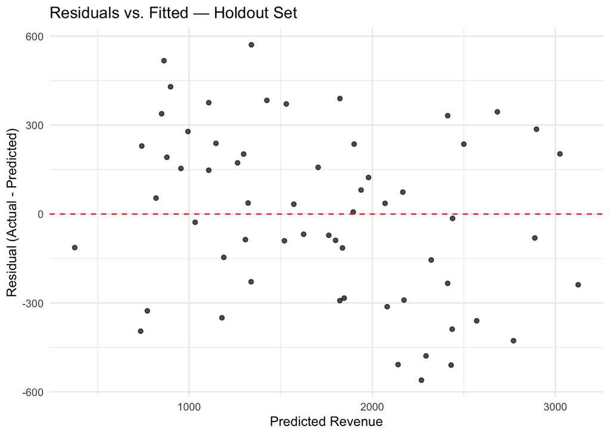

```r
ggplot(data.frame(fitted = pred_test, resid = resid_test), aes(x = fitted, y = resid)) +
  geom_point(alpha = 0.7) +
  geom_hline(yintercept = 0, color = "red", linetype = "dashed") +
  labs(title = "Residuals vs. Fitted — Holdout Set",
       x = "Predicted Revenue", y = "Residual (Actual - Predicted)") +
  theme_minimal()
```

[output not shown]

## Model 2: Logistic Regression — predicting `has_online_delivery`

```r
logistic_model <- glm(has_online_delivery ~ average_cost_two + rating,
                       data = train_data, family = binomial)
summary(logistic_model)
```

```
##
## Call:
## glm(formula = has_online_delivery ~ average_cost_two + rating,
##     family = binomial, data = train_data)
##
## Coefficients:
##                    Estimate Std. Error z value Pr(>|z|)
## (Intercept)      -1.0209763  0.8192912  -1.246    0.213
## average_cost_two  0.0014416  0.0003598   4.007 6.16e-05 ***
## rating            0.1529155  0.2287580   0.668    0.504
## ---
## Signif. codes:  0 '***' 0.001 '**' 0.01 '*' 0.05 '.' 0.1 ' ' 1
##
## (Dispersion parameter for binomial family taken to be 1)
##
##     Null deviance: 161.70  on 139  degrees of freedom
## Residual deviance: 140.21  on 137  degrees of freedom
## AIC: 146.21
##
## Number of Fisher Scoring iterations: 5
```

```r
prob_pred <- predict(logistic_model, newdata = test_data, type = "response")
class_pred <- ifelse(prob_pred > 0.5, 1, 0)

confusion_matrix <- table(Predicted = class_pred, Actual = test_data$has_online_delivery)
print(confusion_matrix)
```

```
##          Actual
## Predicted  0  1
##         0  4  0
##         1 16 40
```

```r
accuracy <- sum(diag(confusion_matrix)) / sum(confusion_matrix)
recall_no_delivery <- confusion_matrix["0", "0"] / sum(confusion_matrix[, "0"])

roc_obj <- roc(test_data$has_online_delivery, prob_pred, quiet = TRUE)
auc_value <- as.numeric(auc(roc_obj))

cat("Holdout accuracy:", round(accuracy, 3), "\n")
```

```
## Holdout accuracy: 0.733
```

```r
cat("Holdout AUC:", round(auc_value, 3), "\n")
```

```
## Holdout AUC: 0.765
```

```r
cat("Recall on 'no delivery' restaurants:", round(recall_no_delivery, 3), "\n")
```

```
## Recall on 'no delivery' restaurants: 0.2
```

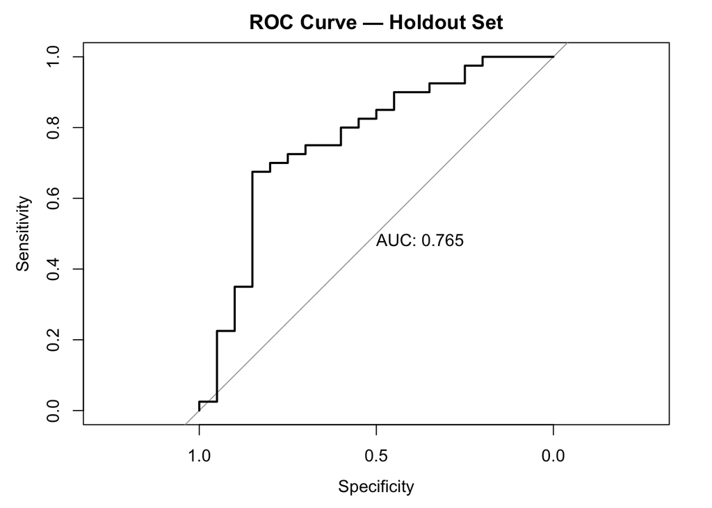

```r
plot(roc_obj, main = "ROC Curve — Holdout Set", print.auc = TRUE)
```

**Reading the panel:** accuracy (73%) and AUC (0.77) both clear a reasonable bar at first glance — this is exactly the trap a headline metric sets. The confusion matrix tells a different story: of the restaurants that genuinely don’t offer delivery, the model correctly flags only about 1 in 5. It has learned to predict “yes, delivery” almost by default, because most restaurants in this data do offer it. If this model fed a delivery-fleet staffing decision, we’d be dramatically under-planning for the offline-only segment — a real operational miss that accuracy and AUC alone never surface. This is why a single headline number is never the whole evaluation.

| Metric | Value | Threshold | Status |
| --- | --- | --- | --- |
| Holdout AUC | 0.77 | ≥ 0.70 | **Within threshold** |
| Holdout accuracy | 73% | ≥ 70% | **Within threshold** |
| Recall, “no delivery” class | ~20% | ≥ 50% | **Flagged** |

## Model 3: Decision Tree — predicting `price_range`

This is the deliberately broken example. We fit a tree with **no size limit at all** (`cp = 0, minsplit = 2`), using predictors that only loosely relate to price — `rating`, `votes`, `platform`, `distance_center_km` — and see what an unconstrained tree does with weak signal.

```r
overfit_tree <- rpart(price_range ~ rating + votes + platform + distance_center_km,
                       data = train_data, method = "class",
                       control = rpart.control(cp = 0, minsplit = 2, minbucket = 1))

train_acc_overfit <- mean(predict(overfit_tree, train_data, type = "class") == train_data$price_range)
test_acc_overfit  <- mean(predict(overfit_tree, test_data, type = "class") == test_data$price_range)

cat("Tree size:", sum(overfit_tree$frame$var != "<leaf>"), "splits\n")
```

```
## Tree size: 69 splits
```

```r
cat("Training accuracy:", round(train_acc_overfit, 3), "\n")
```

```
## Training accuracy: 1
```

```r
cat("Holdout accuracy:", round(test_acc_overfit, 3), "\n")
```

```
## Holdout accuracy: 0.4
```

**Confirmation re-run:** `rpart` already cross-validates internally as it grows the tree, recording a cross-validated error (`xerror`) at every candidate size in `cptable`. This is the same confirm-before-you-trust-it step as the holdout re-run above, done automatically.

```r
printcp(overfit_tree)
```

```
##
## Classification tree:
## rpart(formula = price_range ~ rating + votes + platform + distance_center_km,
##     data = train_data, method = "class", control = rpart.control(cp = 0,
##         minsplit = 2, minbucket = 1))
##
## Variables actually used in tree construction:
## [1] distance_center_km platform           rating             votes
##
## Root node error: 90/140 = 0.64286
##
## n= 140
##
##           CP nsplit rel error  xerror     xstd
## 1  0.1888889      0  1.000000 1.11111 0.059391
## 2  0.0250000      1  0.811111 0.82222 0.065627
## 3  0.0222222      5  0.711111 0.94444 0.064207
## 4  0.0166667     10  0.600000 0.95556 0.063994
## 5  0.0111111     12  0.566667 1.00000 0.062994
## 6  0.0098765     39  0.233333 1.12222 0.058937
## 7  0.0088889     48  0.144444 1.11111 0.059391
## 8  0.0074074     54  0.088889 1.13333 0.058464
## 9  0.0055556     57  0.066667 1.13333 0.058464
## 10 0.0000000     69  0.000000 1.15556 0.057459
```

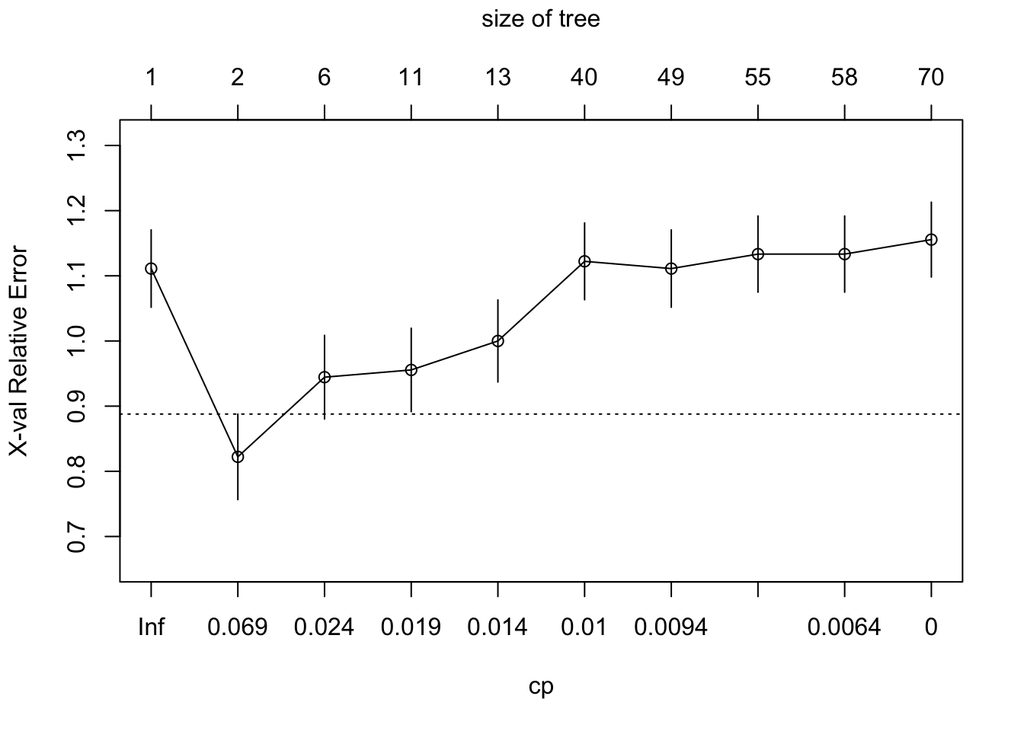

```r
plotcp(overfit_tree)
```

**Fix — prune to the cross-validated best size:**

```r
best_cp <- overfit_tree$cptable[which.min(overfit_tree$cptable[, "xerror"]), "CP"]
pruned_tree <- prune(overfit_tree, cp = best_cp)

train_acc_pruned <- mean(predict(pruned_tree, train_data, type = "class") == train_data$price_range)
test_acc_pruned  <- mean(predict(pruned_tree, test_data, type = "class") == test_data$price_range)

cat("Pruned tree size:", sum(pruned_tree$frame$var != "<leaf>"), "splits\n")
```

```
## Pruned tree size: 1 splits
```

```r
cat("Training accuracy:", round(train_acc_pruned, 3), "\n")
```

```
## Training accuracy: 0.479
```

```r
cat("Holdout accuracy:", round(test_acc_pruned, 3), "\n")
```

```
## Holdout accuracy: 0.417
```

**Reading the fix:** pruning collapses the tree to a single split, and training/holdout accuracy land close together (~48% vs ~42%) instead of 60 points apart. The absolute accuracy is still underwhelming — and that’s the real lesson, not a failure of pruning. Pruning fixed the *overfitting*; it also revealed that `rating`, `votes`, `platform`, and `distance` simply don’t carry much signal about price tier on their own. That’s diagnostics doing its job twice: catching a model that would have shipped with false confidence, and telling the team to go find better features rather than a fancier model.

| Metric | Value | Threshold | Status |
| --- | --- | --- | --- |
| Unpruned: train − holdout accuracy gap | ~60 pts | ≤ 15 pts | **Flagged** |
| Pruned: train − holdout accuracy gap | ~6 pts | ≤ 15 pts | **Within threshold** |

## Model 4: k-Means Clustering — restaurant segments

```r
cluster_features <- scale(restaurant_data[, c("average_cost_two", "rating")])
kmeans_result <- kmeans(cluster_features, centers = 3, nstart = 20)
restaurant_data$cluster <- factor(kmeans_result$cluster)
```

Clustering has no holdout labels to check against — the confirmation re-run here is trying a range of cluster counts and comparing their silhouette scores, the same protocol applied to a different question (“did we pick the right k?” instead of “did we pick the right features?”).

```r
silhouette_by_k <- sapply(2:5, function(k) {
  km <- kmeans(cluster_features, centers = k, nstart = 20)
  mean(silhouette(km$cluster, dist(cluster_features))[, 3])
})
names(silhouette_by_k) <- 2:5
print(round(silhouette_by_k, 3))
```

```
##     2     3     4     5
## 0.378 0.422 0.390 0.402
```

```r
sil_k3 <- silhouette(kmeans_result$cluster, dist(cluster_features))
cat("Average silhouette, k = 3:", round(mean(sil_k3[, 3]), 3), "\n")
```

```
## Average silhouette, k = 3: 0.422
```

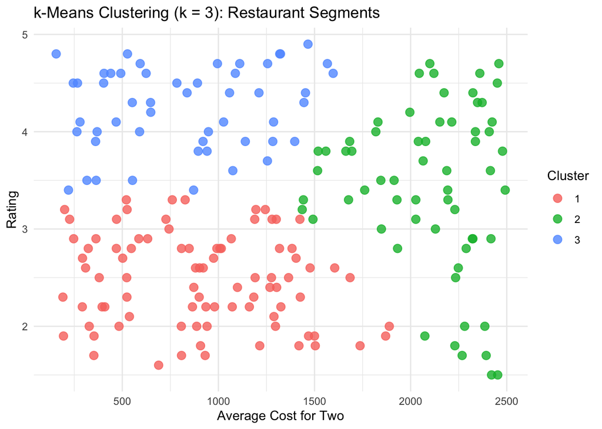

```r
ggplot(restaurant_data, aes(x = average_cost_two, y = rating, color = cluster)) +
  geom_point(size = 3, alpha = 0.8) +
  labs(title = "k-Means Clustering (k = 3): Restaurant Segments",
       x = "Average Cost for Two", y = "Rating", color = "Cluster") +
  theme_minimal()
```

**Reading the panel:** k = 3 is the best of the four values tried, but at 0.42 it sits below our 0.50 bar for “clearly separated” segments — cost and rating alone produce clusters that overlap more than they’re distinct. That’s a useful result to know *before* building a marketing plan around three crisp restaurant personas: the segments are real but fuzzy, so treat cluster boundaries as a starting point for judgment, not a hard rule.

| Metric | Value | Threshold | Status |
| --- | --- | --- | --- |
| Silhouette, best k (k=3) | 0.42 | ≥ 0.50 | **Flagged** |

## Second engine: the same evaluate step, as database aggregate functions

Everything above ran fit/score/evaluate in R, in memory. In production, the same evaluate step usually runs as an aggregate query against the platform’s database instead of pulling every row into R first. `dplyr`’s `group_by()` + `summarise()` grammar is the same grammar `dbplyr` pushes down to a live SQL database with zero code changes — this is what “database analytical functions to fit, score, and evaluate” looks like in practice: the same protocol, a second engine.

```r
restaurant_data$linear_residual <- restaurant_data$estimated_revenue -
  predict(linear_model, newdata = restaurant_data)

restaurant_data %>%
  group_by(platform) %>%
  summarise(
    n_restaurants = n(),
    avg_revenue = round(mean(estimated_revenue), 1),
    avg_abs_error = round(mean(abs(linear_residual)), 1),
    delivery_rate = round(mean(has_online_delivery), 3),
    .groups = "drop"
  )
```

```
## # A tibble: 2 × 5
##   platform n_restaurants avg_revenue avg_abs_error delivery_rate
##   <chr>            <int>       <dbl>         <dbl>         <dbl>
## 1 Swiggy             111       1642.          242.         0.712
## 2 Zomato              89       1776.          277.         0.719
```

```r
restaurant_data %>%
  group_by(price_range) %>%
  summarise(
    n_restaurants = n(),
    delivery_rate = round(mean(has_online_delivery), 3),
    avg_rating = round(mean(rating), 2),
    .groups = "drop"
  )
```

```
## # A tibble: 4 × 4
##   price_range n_restaurants delivery_rate avg_rating
##   <fct>               <int>         <dbl>      <dbl>
## 1 Budget                 25         0.4         3.08
## 2 Moderate               31         0.516       3.45
## 3 Premium                77         0.753       3.06
## 4 Luxury                 67         0.881       3.36
```

**Reading the panel:** the platform-level breakdown confirms the linear model’s error is stable across Zomato and Swiggy (no platform is quietly dragging the average down), and the price-tier breakdown shows delivery rate climbing steadily from Budget (40%) to Luxury (88%) — consistent with the coefficient logistic regression found, and a sanity check that would take one query to re-run against a live production table with no R involved at all.

## Summary: every model, one glance

[output not shown]

Three of seven checks are flagged — and that’s the point of running diagnostics on every model, not just the ones that feel shaky. A model can look production-ready on its headline metric and still fail a component check that matters more to the business than the headline does.